# Code used to generate paper results : Database comparison and CT characteristics

Julie Devis

2023-08-28

# 1 Loading data and packages

```r
.libPaths("/storage/research/dduv/cbio-lg/rlib/Bioc318/", include.site = FALSE)
library(readxl)
library(readr)
library(CTexploreR)
library(Vennerable)
library(biomaRt)
library(tidyverse)
library(SummarizedExperiment)
library(UpSetR)
library(ComplexHeatmap)
library(circlize)
library(SingleCellExperiment)
library(org.Hs.eg.db)
library(clusterProfiler)
library(msigdbr)
library(DOSE)
library(BiocParallel)
library(patchwork)
library(Biostrings)
```

Gene names/synonyms required for databases cleaning

```r
ensembl <- biomaRt::useDataset("hsapiens_gene_ensembl", useMart("ensembl"))
attributes_vector <- c("ensembl_gene_id", "external_gene_name",
                       "external_synonym", "gene_biotype",
                       "chromosome_name", "band", "start_position", "end_position",
                       "strand")
ensembl_gene_synonym <- as_tibble(getBM(attributes = attributes_vector, mart = ensembl))

ensembl_gene_synonym <- ensembl_gene_synonym %>%
  mutate(external_synonym = sub(pattern = "ORF", external_synonym,
                                replacement = "orf"))

attributes_vector <- c("ensembl_gene_id", "external_gene_name")
ensembl_gene_names <- as_tibble(getBM(attributes = attributes_vector, mart = ensembl))
```

```r
GTEX_data <- CTdata::GTEX_data()
normal_tissues_multimapping_data <- CTdata::normal_tissues_multimapping_data()
CCLE_data <- CTdata::CCLE_data()
TCGA_TPM <- CTdata::TCGA_TPM()
DAC_treated_cells_multimapping <- CTdata::DAC_treated_cells_multimapping()
testis_sce <- CTdata::testis_sce()
scRNAseq_HPA <- CTdata::scRNAseq_HPA()
CT_mean_methylation_in_tissues <- CTdata::CT_mean_methylation_in_tissues()
```

Common figures parameters

```r
legends_param <- list(
  labels_gp = gpar(col = "black", fontsize = 6),
  title_gp = gpar(col = "black", fontsize = 6),
  row_names_gp = gpar(fontsize = 4),
  annotation_name_side = "left")

legend_colors <- c("#5E4FA2", "#3288BD", "#66C2A5", "#ABDDA4", "#E6F598",
                   "#FFFFBF", "#FEE08B", "#FDAE61", "#F46D43", "#D53E4F",
                   "#9E0142")
chr_colors <- c("X-linked" = "deeppink", "Not X" = "royalblue1")

meth_colors <- c("Methylation" = "lightgreen", "Not methylation" = "gray")
```

# 2 Database comparison

## 2.1 Lists cleaning

CT lists from other databases have been checked (using GTEx and our `GTEx_expression()` funtion and GeneCards) in order to remove duplicated gene names or deprecated ones and allow comparison between databases.

### 2.1.1 CTdatabase

Online list copied in a csv file, several lists exist so we combined them.

We checked gene names that were a concetanation of two genes (choice using biomaRt synonyms to get the official one), checked which ones had the right names, removed duplicated genes, verified lost genes and added back those that should be there.

```r
CTdatabase <- read_delim("data/CTdatabase1.csv", delim = ";",
                         escape_double = FALSE, trim_ws = TRUE)
colnames(CTdatabase) <- c("Family", "Gene_Name", "Chromosomal_localization",
                          "CT_identifier")
CTdatabase_bis <- read_csv2("data/CTdatabase2.csv")
CTdatabase <- left_join(CTdatabase, CTdatabase_bis,
                        by = c("Gene_Name" = "Gene_Symbol"))


CTdatabase_single <- CTdatabase %>%
  mutate(Gene_Name = sub(pattern = "/.*$", Gene_Name, replacement = ""))
CTdatabase_single <- CTdatabase_single %>%
  mutate(Gene_Name = sub(pattern = ",.*$", Gene_Name, replacement = ""))


CTdatabase_official_names <-
  unique(dplyr::select(ensembl_gene_synonym, ensembl_gene_id,
                       external_gene_name)) %>%
  filter(external_gene_name %in% CTdatabase_single$Gene_Name) %>%
  mutate(Gene_Name = external_gene_name) %>%
  mutate(external_synonym = NA)
CTdatabase_synonym <-
  ensembl_gene_synonym %>%
  filter(external_synonym %in% CTdatabase_single$Gene_Name) %>%
  mutate(Gene_Name = external_synonym) %>%
  dplyr::select(ensembl_gene_id, external_gene_name, Gene_Name, external_synonym)
CTdatabase_cleaned <-
  rbind(CTdatabase_official_names, CTdatabase_synonym) %>%
  left_join(CTdatabase_single)


duplicated_genes <- CTdatabase_cleaned$Gene_Name[duplicated(CTdatabase_cleaned$Gene_Name)]
bad_ids <- ensembl_gene_synonym %>%
  filter(external_gene_name %in% duplicated_genes | external_synonym %in% duplicated_genes) %>%
  filter(chromosome_name %in% grep(pattern = "H", x = chromosome_name, value = TRUE)) %>%
  pull(ensembl_gene_id)
CTdatabase_cleaned <- CTdatabase_cleaned %>%
  dplyr::filter(!ensembl_gene_id %in% bad_ids)
CTdatabase_cleaned <- CTdatabase_cleaned %>%
  filter(!ensembl_gene_id == "ENSG00000052126")
CTdatabase_cleaned <- CTdatabase_cleaned %>%
  filter(!(ensembl_gene_id == "ENSG00000183305" & Gene_Name == "MAGEA2"))
CTdatabase_cleaned <- CTdatabase_cleaned %>%
  filter(!ensembl_gene_id == "ENSG00000204648")
CTdatabase_cleaned <- filter(CTdatabase_cleaned, Gene_Name != "CSAG3B")
CTdatabase_cleaned[CTdatabase_cleaned$Gene_Name == "CSAG2", "external_synonym"] <- "CSAG3B"
CTdatabase_cleaned <- filter(CTdatabase_cleaned, Gene_Name != "CT45A4")
CTdatabase_cleaned[CTdatabase_cleaned$Gene_Name == "CT45A3", "external_synonym"] <- "CT45A4"
CTdatabase_cleaned <- filter(CTdatabase_cleaned, Gene_Name != "LAGE-1b")
CTdatabase_cleaned[CTdatabase_cleaned$Gene_Name == "CTAG2", "external_synonym"] <- "LAGE-1b"
CTdatabase_cleaned <- filter(CTdatabase_cleaned, Gene_Name != "CT16.2")
CTdatabase_cleaned[CTdatabase_cleaned$Gene_Name == "PAGE5", "external_synonym"] <- "CT16.2"
CTdatabase_cleaned <- filter(CTdatabase_cleaned, Gene_Name != "SPANXB2")
CTdatabase_cleaned[CTdatabase_cleaned$Gene_Name == "SPANXB1", "external_synonym"] <- "SPANXB2"
CTdatabase_cleaned <- filter(CTdatabase_cleaned, Gene_Name != "SPANXE")
CTdatabase_cleaned[CTdatabase_cleaned$Gene_Name == "SPANXD", "external_synonym"] <- "SPANXE"
CTdatabase_cleaned <- filter(CTdatabase_cleaned, Gene_Name != "XAGE1C")
CTdatabase_cleaned <- filter(CTdatabase_cleaned, Gene_Name != "XAGE1D")
CTdatabase_cleaned <- filter(CTdatabase_cleaned, Gene_Name != "XAGE1E")
CTdatabase_cleaned <- filter(CTdatabase_cleaned, Gene_Name != "XAGE2B")
CTdatabase_cleaned[CTdatabase_cleaned$Gene_Name == "XAGE2", "external_synonym"] <- "XAGE2B"
CTdatabase_cleaned <- filter(CTdatabase_cleaned, Gene_Name != "CTAGE-2")
CTdatabase_cleaned[CTdatabase_cleaned$Gene_Name == "CTAGE1", "external_synonym"] <- "CTAGE-2"


CTdatabase_cleaned <- ensembl_gene_synonym %>%
  mutate(Gene_Name = external_synonym) %>%
  filter(external_synonym == "CXorf61") %>%
  dplyr::select(ensembl_gene_id, external_gene_name, Gene_Name, external_synonym) %>%
  cbind(CTdatabase_single[CTdatabase_single$Gene_Name == "Cxorf61",
                    c("Family", "Chromosomal_localization", "CT_identifier", "Classification")]) %>%
  rbind(CTdatabase_cleaned)
CTdatabase_cleaned <- unique(dplyr::select(ensembl_gene_synonym, ensembl_gene_id, external_gene_name)) %>%
  filter(external_gene_name == "CCNA1") %>%
  mutate(Gene_Name = external_gene_name) %>%
  mutate(external_synonym = NA) %>%
  cbind(CTdatabase_single[CTdatabase_single$Gene_Name == "cyclin A1",
                          c("Family", "Chromosomal_localization", "CT_identifier", "Classification")]) %>%
  rbind(CTdatabase_cleaned)
CTdatabase_cleaned <- unique(dplyr::select(ensembl_gene_synonym, ensembl_gene_id, external_gene_name))%>%
  filter(external_gene_name == "GOLGA6L2") %>%
  filter(ensembl_gene_id == "ENSG00000174450") %>%
  mutate(Gene_Name = external_gene_name) %>%
  mutate(external_synonym = NA) %>%
  cbind(CTdatabase_single[CTdatabase_single$Gene_Name == "GOLGAGL2 FA",
                          c("Family", "Chromosomal_localization", "CT_identifier", "Classification")]) %>%
  rbind(CTdatabase_cleaned)
CTdatabase_cleaned <- unique(dplyr::select(ensembl_gene_synonym, ensembl_gene_id, external_gene_name))%>%
  filter(external_gene_name == "LYPD6B") %>%
  mutate(Gene_Name = external_gene_name) %>%
  mutate(external_synonym = NA) %>%
  cbind(CTdatabase_single[CTdatabase_single$Gene_Name == "LOC130576",
                          c("Family", "Chromosomal_localization", "CT_identifier", "Classification")]) %>%
  rbind(CTdatabase_cleaned)
CTdatabase_cleaned <- unique(dplyr::select(ensembl_gene_synonym, ensembl_gene_id, external_gene_name))%>%
  filter(external_gene_name == "CT62") %>%
  mutate(Gene_Name = external_gene_name) %>%
  mutate(external_synonym = NA) %>%
  cbind(CTdatabase_single[CTdatabase_single$Gene_Name == "LOC196993",
                          c("Family", "Chromosomal_localization", "CT_identifier", "Classification")]) %>%
  rbind(CTdatabase_cleaned)
CTdatabase_cleaned <- unique(dplyr::select(ensembl_gene_synonym, ensembl_gene_id, external_gene_name))%>%
  filter(external_gene_name == "CT75") %>%
  filter(ensembl_gene_id == "ENSG00000291155") %>%
  mutate(Gene_Name = external_gene_name) %>%
  mutate(external_synonym = NA) %>%
  cbind(CTdatabase_single[CTdatabase_single$Gene_Name == "LOC440934",
                          c("Family", "Chromosomal_localization", "CT_identifier", "Classification")]) %>%
  rbind(CTdatabase_cleaned)
CTdatabase_cleaned <- unique(dplyr::select(ensembl_gene_synonym, ensembl_gene_id, external_gene_name))%>%
  filter(external_gene_name == "LINC01192") %>%
  mutate(Gene_Name = external_gene_name) %>%
  mutate(external_synonym = NA) %>%
  cbind(CTdatabase_single[CTdatabase_single$Gene_Name == "LOC647107",
                          c("Family", "Chromosomal_localization", "CT_identifier", "Classification")]) %>%
  rbind(CTdatabase_cleaned)
CTdatabase_cleaned <- unique(dplyr::select(ensembl_gene_synonym, ensembl_gene_id, external_gene_name))%>%
  filter(external_gene_name == "TSPY1") %>%
  mutate(Gene_Name = external_gene_name) %>%
  mutate(external_synonym = NA) %>%
  cbind(CTdatabase_single[CTdatabase_single$Gene_Name == "LOC728137",
                          c("Family", "Chromosomal_localization", "CT_identifier", "Classification")]) %>%
  rbind(CTdatabase_cleaned)
CTdatabase_cleaned <- unique(dplyr::select(ensembl_gene_synonym, ensembl_gene_id, external_gene_name))%>%
  filter(external_gene_name == "SSX2B") %>%
  mutate(Gene_Name = external_gene_name) %>%
  mutate(external_synonym = NA) %>%
  cbind(CTdatabase_single[CTdatabase_single$Gene_Name == "SSX2b",
                          c("Family", "Chromosomal_localization", "CT_identifier", "Classification")]) %>%
  rbind(CTdatabase_cleaned)
```

### 2.1.2 Jamin’s list

Excel file coming from supplemental data.

```r
Jamin_core_CT <- read_excel("data/Jamin_core_CT.xlsx")
Jamin_core_CT[Jamin_core_CT$Gene == "KIAA1211", "Gene"] <- "CRACD"
Jamin_core_CT[Jamin_core_CT$Gene == "CXorf67", "Gene"] <- "EZHIP"
```

### 2.1.3 Wang’s CTatlas

Excel file coming from supplemental data.

```r
Wang_CT <- read_excel("data/Wang_Suppl_Data_3.xlsx",
    sheet = "Supplementary Data 3B", skip = 1)
colnames(Wang_CT)[1] <- "ensembl_gene_id"

Wang_CT <- ensembl_gene_names %>%
  filter(ensembl_gene_id %in% Wang_CT$ensembl_gene_id) %>%
  right_join(Wang_CT)

Wang_CT[Wang_CT$ensembl_gene_id == "ENSG00000181013", "external_gene_name"] <- "C17orf47"
Wang_CT[Wang_CT$ensembl_gene_id == "ENSG00000204293", "external_gene_name"] <- "OR8B2"
Wang_CT[Wang_CT$external_gene_name == "", "external_gene_name"] <- "RNASE11"
Wang_CT[Wang_CT$external_gene_name == "CHCT1", "external_gene_name"] <- "C17orf64"
Wang_CT[Wang_CT$external_gene_name == "PRSS40A", "external_gene_name"] <- "TISP43"
Wang_CT[Wang_CT$external_gene_name == "TEX56P", "external_gene_name"] <- "C6orf201"
Wang_CT[Wang_CT$external_gene_name == "SLC25A51P4", "external_gene_name"] <- "RP11-113D6.10"
Wang_CT[Wang_CT$external_gene_name == "TCP10L3", "external_gene_name"] <- "TCP10"
Wang_CT[Wang_CT$external_gene_name == "SCAND3", "external_gene_name"] <- "ZBED9"
```

### 2.1.4 Carter’s list

```r
Carter_CT_list <- read_table("data/Carter_CT_list.txt", skip = 1)
Carter_CT <- Carter_CT_list[Carter_CT_list$CT_Expression,]

Carter_CT[Carter_CT$Gene == "ENSG00000261649", "Gene_Name"] <- "GOLGA6L7"
Carter_CT[Carter_CT$Gene == "ENSG00000239620", "Gene_Name"] <- "PRR20G"
Carter_CT[Carter_CT$Gene == "ENSG00000168148", "Gene_Name"] <- "H3-4"
Carter_CT[Carter_CT$Gene == "ENSG00000204296", "Gene_Name"] <- "TSBP1"
Carter_CT[Carter_CT$Gene == "ENSG00000180219", "Gene_Name"] <- "GARIN6"
Carter_CT[Carter_CT$Gene == "ENSG00000172717", "Gene_Name"] <- "GARIN2"
Carter_CT[Carter_CT$Gene == "ENSG00000174015", "Gene_Name"] <- "CBY2"
Carter_CT[Carter_CT$Gene == "ENSG00000224960", "Gene_Name"] <- "PPP4R3C"
```

## 2.2 CTexploreR data for selection pipeline

To characterise the differences between our database and other, we need the category we created in CTexploreR.

Hereunder is what we used for our selection pipeline (coming from `make_CT_list.R` in `CTdata`), mainly how we created the data.

```r
# GTEX data with the tissue specificity category determined
all_genes <- as_tibble(rowData(GTEX_data), rownames = "ensembl_gene_id")
all_genes$TPM_testis <- assay(GTEX_data)[, "Testis"]

# Add multimapping_analysis assessing testis-specificity of genes "lowly_expressed"

all_genes <- all_genes %>%
  left_join(as_tibble(rowData(normal_tissues_multimapping_data),
                      rownames = "ensembl_gene_id"))

# Summarise both specificity

all_genes <- all_genes %>%
  mutate(testis_specificity = case_when(
    GTEX_category == "testis_specific" |
      multimapping_analysis == "testis_specific" ~ "testis_specific",
    GTEX_category == "testis_preferential" ~ "testis_preferential"))

# Add testis scRNA seq highest expressed cell type

all_genes <- all_genes %>%
  left_join(as_tibble(rowData(testis_sce)) %>%
              dplyr::select(external_gene_name, testis_cell_type))

# Add higher in somatic scRNAseq data of normal tissues from the Human Protein Atlas

all_genes <- all_genes %>%
  left_join(as_tibble(rowData(scRNAseq_HPA), rownames = "ensembl_gene_id") %>%
              dplyr::select(ensembl_gene_id, external_gene_name,
                            Higher_in_somatic_cell_type))

# CCLE database analysis added

all_genes <- all_genes %>%
  left_join(as_tibble(rowData(CCLE_data), rownames = "ensembl_gene_id"))
all_genes[is.na(all_genes$CCLE_category), "CCLE_category"] <- "not_in_CCLE"


# TCGA database analysis added

all_genes <- all_genes %>%
  left_join(as_tibble(rowData(TCGA_TPM), rownames = "ensembl_gene_id") %>%
              dplyr::select(ensembl_gene_id, external_gene_name, percent_pos_tum,
                            percent_neg_tum, max_TPM_in_TCGA, TCGA_category))

all_genes[all_genes$lowly_expressed_in_GTEX == TRUE &
            all_genes$multimapping_analysis == "testis_specific",
          "TCGA_category"] <- "multimapping_issue"

# Add DAC analysis
induced <- as_tibble(rowData(DAC_treated_cells_multimapping),
                     rownames = "ensembl_gene_id") %>%
  filter(induced == TRUE) %>%
  pull(external_gene_name)

all_genes <- all_genes %>%
  mutate(DAC_induced = case_when(external_gene_name %in% induced ~ TRUE,
                                 !external_gene_name %in% induced ~ FALSE))

# Add the most biologically relevant transcript (canonical and coordinates)

ensembl <- biomaRt::useDataset("hsapiens_gene_ensembl", useMart("ensembl"))
attributes_vector <- c("ensembl_gene_id",
                       "external_gene_name",
                       "ensembl_transcript_id",
                       "external_transcript_name",
                       "chromosome_name",
                       "strand",
                       "transcript_start",
                       "transcript_end",
                       "transcription_start_site",
                       "transcript_length",
                       "transcript_biotype",
                       "transcript_is_canonical")
transcripts_infos <- as_tibble(biomaRt::getBM(attributes = attributes_vector,
                                              mart = ensembl))
canonical_transcripts <- transcripts_infos %>%
  filter(transcript_is_canonical == 1) %>%
  filter(chromosome_name %in% c(1:22, "X", "Y", "MT")) %>%
  filter(transcript_biotype == "protein_coding" | transcript_biotype == "lncRNA")
all_genes <- all_genes %>%
  left_join(canonical_transcripts %>%
              dplyr::select(ensembl_gene_id,
                            external_transcript_name, ensembl_transcript_id,
                            chromosome_name, strand, transcript_start,
                            transcript_end, transcription_start_site,
                            transcript_length, transcript_biotype))
```

## 2.3 CTexploreR VS CTdatabase

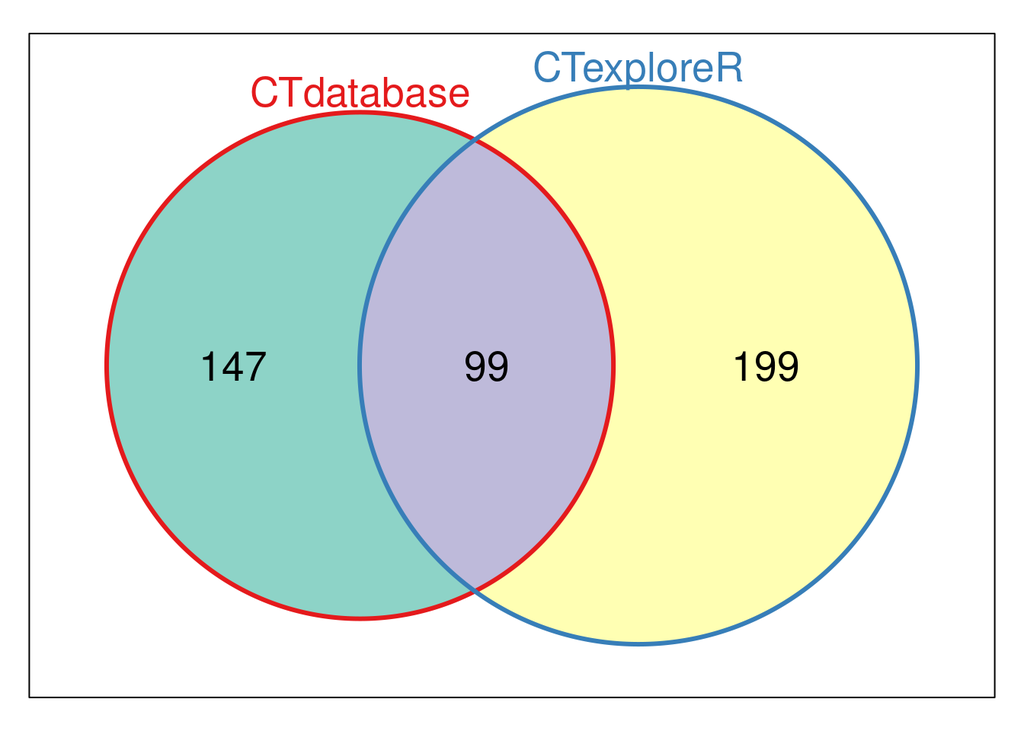

```r
CTdatabase_ours <- Venn(list(CTdatabase = CTdatabase_cleaned$external_gene_name,
                             CTexploreR = CT_genes$external_gene_name))
plot(CTdatabase_ours)
```

## 2.4 CTexploreR VS omics databases

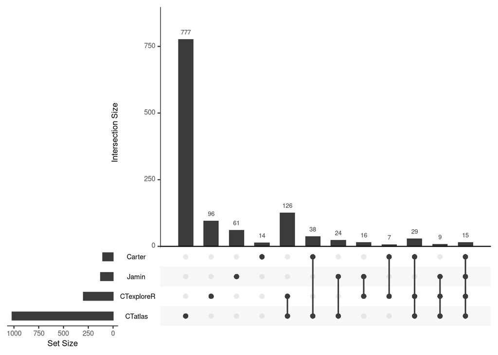

```r
core_ours <- Venn(list(Jamin = Jamin_core_CT$Gene,
                       CTexploreR = CT_genes$external_gene_name))

Wang_ours <- Venn(list(Wang = Wang_CT$external_gene_name,
                       CTexploreR = CT_genes$external_gene_name))

Carter_ours <- Venn(list(Carter_CT = Carter_CT$Gene_Name,
                         CTexploreR = CT_genes$external_gene_name))

gene_list <- list(Jamin = Jamin_core_CT$Gene,
                  CTdatabase = CTdatabase_cleaned$external_gene_name,
                  CTatlas = Wang_CT$external_gene_name,
                  CTexploreR = CT_genes$external_gene_name,
                  Carter = Carter_CT$Gene_Name)

upset_omics <- fromList(gene_list[-2])
upset(upset_omics)
```

## 2.5 Characterisation of differences with all databases

```r
common <- unique(c(core_ours@IntersectionSets[["11"]],
                   CTdatabase_ours@IntersectionSets[["11"]],
                   Wang_ours@IntersectionSets[["11"]],
                   Carter_ours@IntersectionSets[["11"]]))

length(common)
```

```
## [1] 212
```

```r
length(common)/dim(CT_genes)[1] * 100
```

```
## [1] 71.14094
```

```r
lost_list <- unique(c(core_ours@IntersectionSets[["10"]],
                 CTdatabase_ours@IntersectionSets[["10"]],
                 Wang_ours@IntersectionSets[["10"]],
                 Carter_ours@IntersectionSets[["10"]]))

lost <- all_genes %>%
  filter(external_gene_name %in% lost_list)

not_specific <- filter(lost, is.na(testis_specificity))

somatic_testis <- filter(lost, testis_cell_type %in% c( "Macrophage",
                                                        "Endothelial", "Myoid",
                                                        "Sertoli", "Leydig"))

somatic_tissue <- filter(lost, Higher_in_somatic_cell_type == TRUE)

not_TCGA_activated <- filter(lost, TCGA_category != "activated" &
                               TCGA_category != "multimapping_issue")

not_CCLE_activated <- filter(lost, CCLE_category  != "activated")

transcript_prob <- lost %>%
  filter(testis_specificity == "testis_specific" |
           testis_specificity == "testis_preferential") %>%
  filter(TCGA_category == "activated" | TCGA_category == "multimapping_issue") %>%
  filter(CCLE_category == "activated") %>%
  dim()
```

We have lost 979 genes in total. Among them, 58.0183861% are not considered testis specific, 2.8600613% are expressed in testis somatic cells, 11.13381% are expressed in somatic cells, 62.206333% are not activated in TCGA samples, 66.4964249% are not activated in CCLE cell lines and 1.9407559% is lost due to transcripts problems.

# 3 CT genes characteristics

```r
table(CT_genes$testis_specificity)
```

```
##
## testis_preferential     testis_specific
##                  92                 206
```

```r
table(CT_genes$transcript_biotype)
```

```
##
##                  lncRNA nonsense_mediated_decay          protein_coding
##                      48                       3                     247
```

Most genes are testis specific (69.1275168%). Most genes are mainly protein coding genes (82.885906%).

## 3.1 X chromosome and regulated by methylation

In CTexploreR, genes have been characterised as regulated by methylation or not.

```r
table(CT_genes$X_linked)
```

```
##
## FALSE  TRUE
##   205    93
```

```r
table(CT_genes$regulated_by_methylation)
```

```
##
## FALSE  TRUE
##   138   160
```

```r
table(CT_genes$X_linked, CT_genes$regulated_by_methylation)
```

```
##
##         FALSE TRUE
##   FALSE   128   77
##   TRUE     10   83
```

Genes are enriched on the X chromosome (31.2080537%). Also, 160 genes have been flagged as regulated by methylation (53.6912752%). It is interesting to study the link between these two characteristics

On the chromosome X, there is a clear enrichment of CT genes regulated by methylation (83/93 chrX genes or 83/160 genes regulated by methylation).

Let’s check that with a statistical test, I here want to see if, on there is an enrichment of genes regulated by methylation on the X chromosome. I need to do a Pearson Chi square test (to know if observed proportion differ from expected proportion). It is a statistical method to determine if two categorical variables have a significant correlation between them. I can directly put a matrix (my table) in the function

```r
chisq.test(table(CT_genes$X_linked, CT_genes$regulated_by_methylation))
```

```
##
##  Pearson's Chi-squared test with Yates' continuity correction
##
## data:  table(CT_genes$X_linked, CT_genes$regulated_by_methylation)
## X-squared = 66.676, df = 1, p-value = 3.2e-16
```

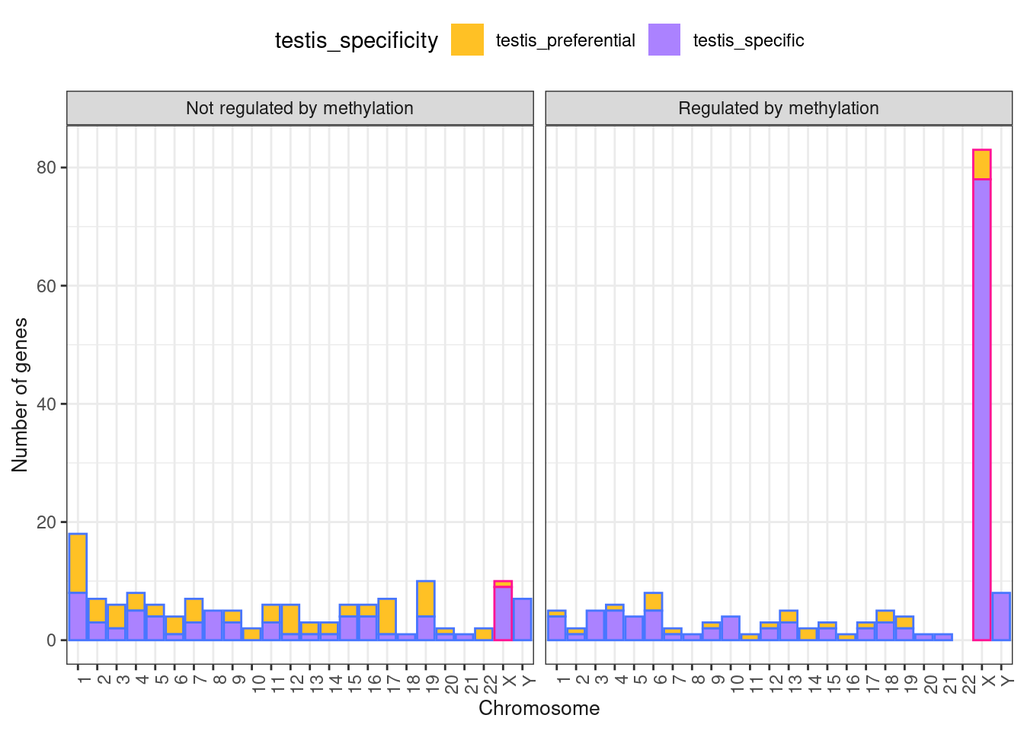

```r
CT_genes$chr_factor <- factor(CT_genes$chr,
                       levels = c("1", "2", "3", "4", "5", "6", "7", "8", "9",
                                  "10", "11", "12", "13", "14", "15", "16", "17",
                                  "18", "19", "20", "21", "22", "X", "Y"))

CT_genes %>%
  mutate(regulated_by_methylation = ifelse(regulated_by_methylation,
                                           "Regulated by methylation",
                                           "Not regulated by methylation")) %>%
  ggplot(aes(x = chr_factor, fill = testis_specificity, color = X_linked)) +
  geom_bar(stat = 'count') +
  scale_fill_manual(values = c("goldenrod1", "mediumpurple1")) +
  scale_color_manual(values = c("royalblue1", "deeppink"), guide = "none") +
  facet_wrap(~ regulated_by_methylation, ncol = 2) +
  theme_bw() +
  xlab("Chromosome") +
  ylab("Number of genes") +
  theme(axis.text.x = element_text(angle = 90, hjust = 1),
        legend.position = "top",
        axis.title = element_text(size = 10, color = "gray10"))
```

There is indeed a significative link between regulation by methylation and being on the X chromosome. There is thus an enrichment of CT genes regulated by methylation on the X chromosome (and inversely).

## 3.2 Tumour and methylation

Using CTexploreR functions, we can explore all CT genes or focus on some potential targets.

### 3.2.1 All CT

For these heatmaps, the code comes from the function but has been copies to add some annotations.

```r
chr_mat <- as.matrix(CT_genes$X_linked)
chr_mat <- ifelse(chr_mat == TRUE, "X-linked", "Not X")
rownames(chr_mat) <- CT_genes$external_gene_name
row_ha_chr <- rowAnnotation(chr_factor = chr_mat,
                            annotation_legend_param = legends_param,
                            simple_anno_size = unit(0.5, "cm"),
                            col = list(chr_factor = chr_colors),
                            annotation_name_gp = gpar(fontsize = 8),
                            annotation_name_side = "top")



regulation_mat <- as.matrix(CT_genes$regulated_by_methylation)
regulation_mat <- ifelse(regulation_mat == TRUE, "Methylation",
                         "Not methylation")
rownames(regulation_mat) <- CT_genes$external_gene_name


row_ha_reg <- rowAnnotation(regulation = regulation_mat,
                            annotation_legend_param = legends_param,
                            simple_anno_size = unit(0.5, "cm"),
                            col = list(regulation = meth_colors),
                            annotation_name_gp = gpar(fontsize = 8),
                            annotation_name_side = "top")

left_annot <- c(row_ha_chr, row_ha_reg, gap = unit(1, "mm"))

split <- data.frame(CT_genes$regulated_by_methylation, CT_genes$X_linked)
```

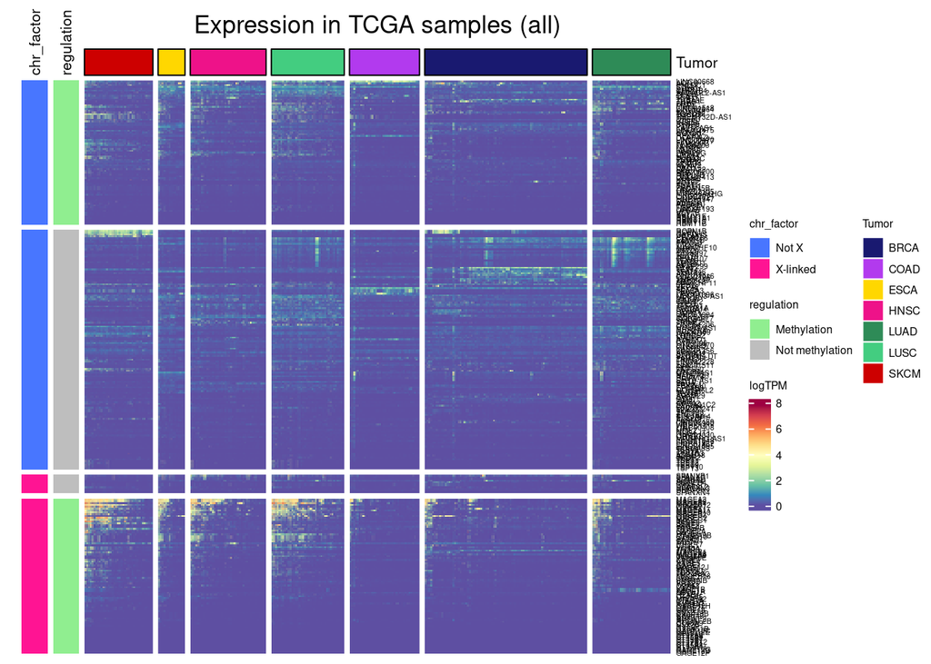

```r
database <- TCGA_TPM
database$tumor <- sub(pattern = 'TCGA-', x = database$project_id, '')
database$type <- "Tumor"
database$type[database$shortLetterCode == "NT"] <- "Peritumoral"
database <- database[, order(database$tumor, database$type)]

genes <- CT_genes$external_gene_name
database <- database[rowData(database)$external_gene_name %in% genes, ]
database <- database[match(genes, rowData(database)$external_gene_name), ]
database <- database[, database$type == "Tumor"]

column_ha_tumor <- HeatmapAnnotation(
  Tumor = database$tumor,
  border = TRUE,
  col = list(Tumor = c("BRCA" = "midnightblue", "COAD" = "darkorchid2",
                 "ESCA" = "gold", "HNSC" = "deeppink2",
                 "LUAD" = "seagreen", "LUSC" = "seagreen3",
                 "SKCM" = "red3")),
  annotation_name_gp = gpar(fontsize = 8),
  annotation_legend_param = legends_param)

split_by <- factor(database$tumor)
col_annot <- column_ha_tumor

mat <- log1p(assay(database))
rownames(mat) <- rowData(database)$external_gene_name


Heatmap(mat[, , drop = FALSE],
        name = "logTPM",
        column_title = paste0("Expression in TCGA samples (all)"),
        column_split = split_by,
        row_split = split,
        row_title_gp = gpar(fontsize = 0),
        col = colorRamp2(seq(0, max(mat), length = 11),
                         legend_colors),
        clustering_method_rows = "ward.D",
        clustering_method_columns = "ward.D",
        cluster_rows = TRUE,
        show_column_names = FALSE,
        cluster_columns = TRUE,
        show_column_dend = FALSE,
        show_row_dend = FALSE,
        row_names_gp = gpar(fontsize = 4),
        heatmap_legend_param = legends_param,
        top_annotation = col_annot,
        left_annotation = left_annot)
```

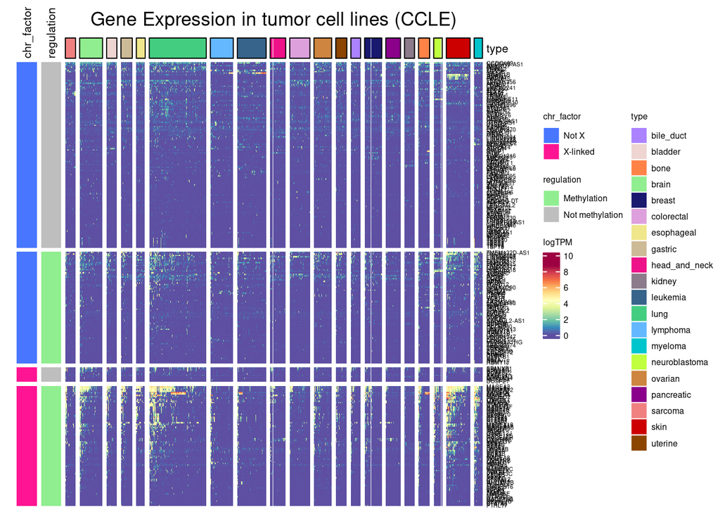

```r
database <- CCLE_data
database$type <- tolower(database$type)
genes <- CT_genes$external_gene_name
database <- database[rowData(database)$external_gene_name %in% genes, ]
database <- database[match(genes, rowData(database)$external_gene_name), ]

mat <- log1p(assay(database))
rownames(mat) <- rowData(database)$external_gene_name

df_col <- data.frame("cell_line" = colData(database)$cell_line_name,
                     "type" = as.factor(colData(database)$type))
rownames(df_col) <- rownames(colData(database))
df_col <- df_col[order(df_col$type), ]

column_ha_type <- HeatmapAnnotation(
  type = df_col$type,
  border = TRUE,
  annotation_name_gp = gpar(fontsize = 8),
  annotation_legend_param = legends_param,
  col = list(type = c("lung" = "seagreen3", "skin" = "red3",
                 "bile_duct" = "mediumpurple1", "bladder" = "mistyrose2",
                 "colorectal" = "plum", "lymphoma" = "steelblue1",
                 "uterine" = "darkorange4", "myeloma" = "turquoise3",
                 "kidney" = "thistle4",
                 "pancreatic" = "darkmagenta", "brain" = "palegreen2",
                 "gastric" = "wheat3", "breast" = "midnightblue",
                 "bone" = "sienna1", "head_and_neck" = "deeppink2",
                 "ovarian" = "tan3", "sarcoma" = "lightcoral",
                 "leukemia" = "steelblue4", "esophageal"= "khaki",
                 "neuroblastoma" = "olivedrab1")))



Heatmap(mat[, rownames(df_col), drop = FALSE],
        name = "logTPM",
        column_title = "Gene Expression in tumor cell lines (CCLE)",
        column_split = factor(df_col$type),
        row_split = split,
        row_title_gp = gpar(fontsize = 0),
        col = colorRamp2(seq(0, max(mat), length = 11),
                          legend_colors),
        clustering_method_rows = "ward.D",
        clustering_method_columns = "ward.D",
        cluster_rows = TRUE,
        show_row_dend = FALSE,
        show_column_names = FALSE,
        cluster_columns = TRUE,
        show_column_dend = FALSE,
        row_names_gp = gpar(fontsize = 4),
        heatmap_legend_param = legends_param,
        top_annotation = c(column_ha_type),
        left_annotation = left_annot)
```

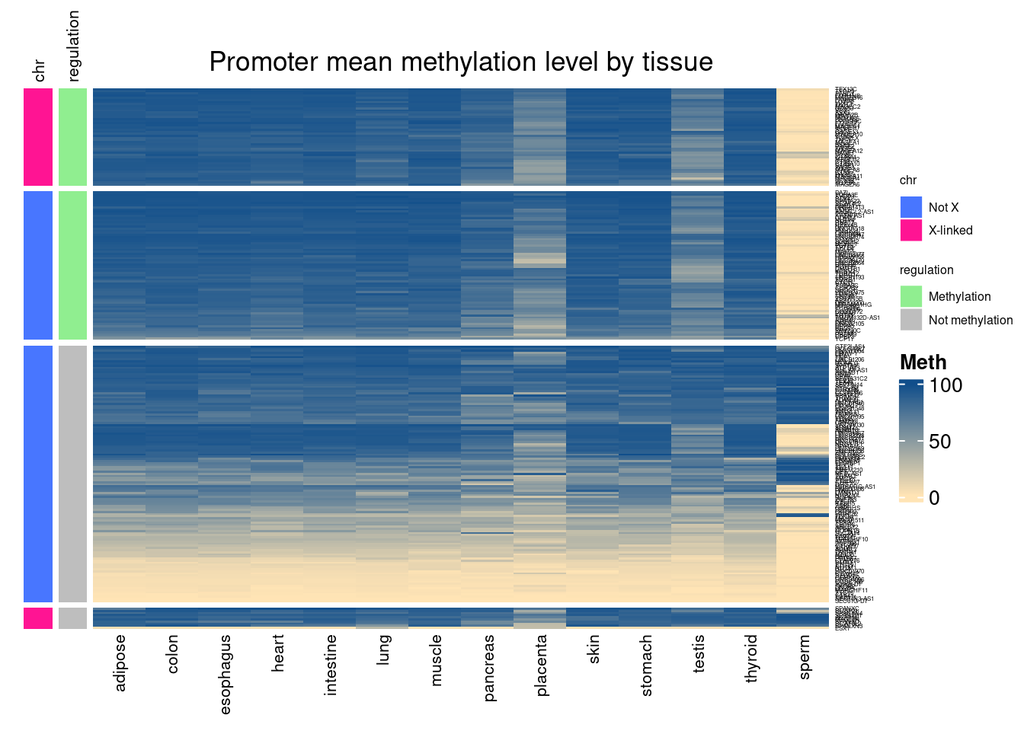

```r
genes <- CT_genes$external_gene_name
database <- CT_mean_methylation_in_tissues[rownames(CT_mean_methylation_in_tissues) %in% genes]

mat <- na.omit(assay(database))
clustering_option <- TRUE

row_ha_chr_meth <- rowAnnotation(chr = chr_mat[rownames(mat),],
                            annotation_legend_param = legends_param,
                            simple_anno_size = unit(0.5, "cm"),
                            col = list(chr = chr_colors),
                            annotation_name_gp = gpar(fontsize = 8),
                            annotation_name_side = "top")


row_ha_reg_meth <- rowAnnotation(regulation = regulation_mat[rownames(mat),],
                            annotation_legend_param = legends_param,
                            simple_anno_size = unit(0.5, "cm"),
                            col = list(regulation = meth_colors),
                            annotation_name_gp = gpar(fontsize = 8),
                            annotation_name_side = "top")

left_annot_meth <- c(row_ha_chr_meth, row_ha_reg_meth, gap = unit(1, "mm"))

split_meth <- data.frame(filter(CT_genes, external_gene_name %in% rownames(mat))$regulated_by_methylation,
                    filter(CT_genes, external_gene_name %in% rownames(mat))$X_linked)

Heatmap(mat,
        column_title = 'Promoter mean methylation level by tissue',
        name = 'Meth',
        col = colorRamp2(c(1:100),
                         colorRampPalette(c("moccasin","dodgerblue4"))(100)),
        na_col = "gray80",
        cluster_rows = clustering_option,
        cluster_columns = FALSE,
        row_split = split_meth,
        row_title_gp = gpar(fontsize = 0),
        show_row_names = TRUE,
        show_heatmap_legend = TRUE,
        show_row_dend = FALSE,
        row_names_gp = gpar(fontsize = 3),
        column_names_gp = gpar(fontsize = 8),
        column_names_side = "bottom",
        row_names_side = "right",
        left_annotation = left_annot_meth)
```

### 3.2.2 MAGE genes

```r
MAGE_genes <- filter(CT_genes, family == "MAGE")$external_gene_name

TCGA_expression(tumor = "all",
                genes = MAGE_genes,
                units = "log_TPM")
```

```
## `use_raster` is automatically set to TRUE for a matrix with more than
## 2000 columns You can control `use_raster` argument by explicitly
## setting TRUE/FALSE to it.
##
## Set `ht_opt$message = FALSE` to turn off this message.
```

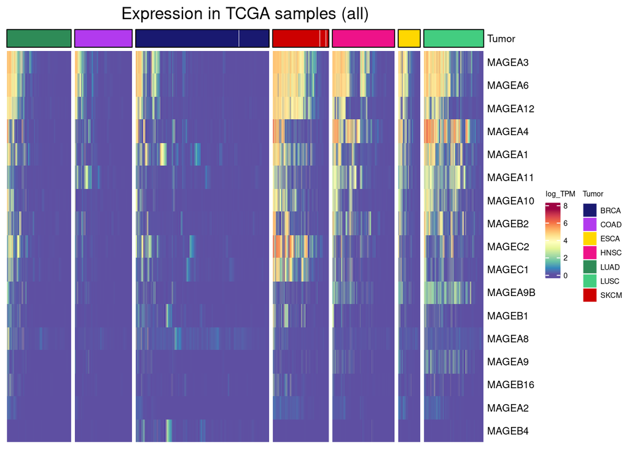

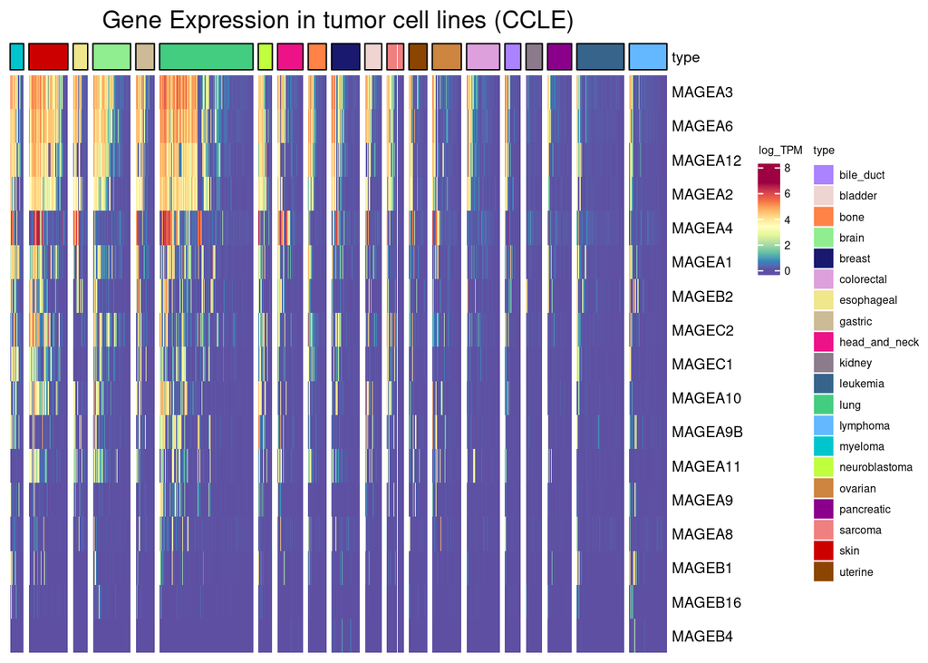

```r
CCLE_expression(genes = MAGE_genes,
                 type = c("lung", "skin", "bile_duct", "bladder",
                          "colorectal", "lymphoma", "uterine",
                          "myeloma", "kidney", "pancreatic", "brain",
                          "gastric", "breast", "bone", "head_and_neck",
                          "ovarian", "sarcoma", "leukemia", "esophageal",
                          "neuroblastoma"), units = "log_TPM")
```

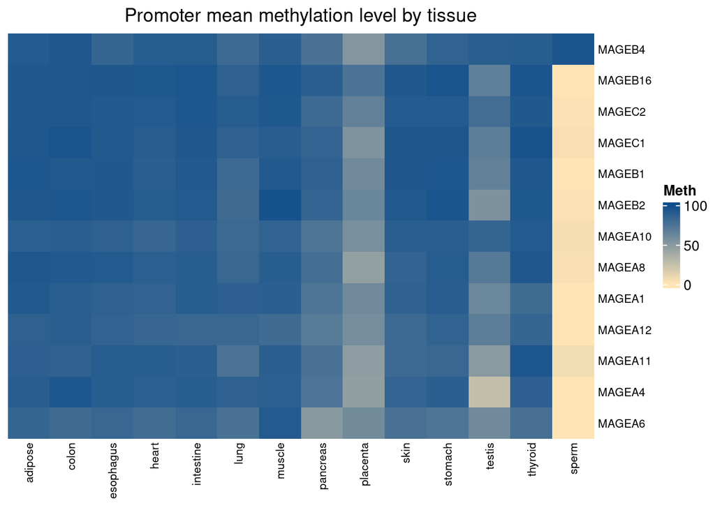

```r
normal_tissues_mean_methylation(MAGE_genes, na.omit = TRUE)
```

## 3.3 Single Cell analysis : timing of expression

In CTexploreR, we there is single cell data from the testis, we thus can analyse CT genes expression during spermatogenesis.

There is only data for 251 of our 298 CT genes.

NB : SSC, Spermatogonia and early spermatocytes are *premeiotic cells*. Late spermatocytes (between both meiosis), round spermatid, elongated spermatid and sperm are *postmeiotic cells*.

```r
genes_avail <-
  CT_genes$external_gene_name[CT_genes$external_gene_name %in% unique(rownames(testis_sce))]
table(CT_genes$testis_cell_type)
```

```
##
##  Early_spermatocyte Elongated_spermatid   Late_spermatocyte     Round_spermatid
##                  41                  25                  23                  64
##              Sperm1              Sperm2       Spermatogonia                 SSC
##                  12                  14                  29                  33
```

```r
table(CT_genes$testis_cell_type)/length(genes_avail)*100
```

```
##
##  Early_spermatocyte Elongated_spermatid   Late_spermatocyte     Round_spermatid
##           16.334661            9.960159            9.163347           25.498008
##              Sperm1              Sperm2       Spermatogonia                 SSC
##            4.780876            5.577689           11.553785           13.147410
```

41% of genes are mainly expressed pre-meioticly.

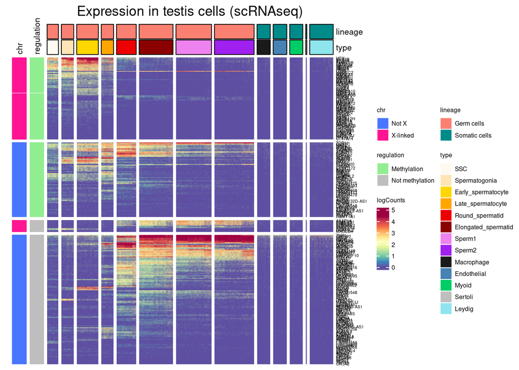

```r
germ_cells <- c("SSC", "Spermatogonia", "Early_spermatocyte",
                "Late_spermatocyte","Round_spermatid", "Elongated_spermatid",
                "Sperm1", "Sperm2")
somatic_cells <- c("Macrophage", "Endothelial", "Myoid", "Sertoli", "Leydig")

testis_sce_CT <- testis_sce[genes_avail, ]

mat <- SingleCellExperiment::logcounts(testis_sce_CT)

df_col <- data.frame(clusters = colData(testis_sce_CT)$clusters,
                     type = colData(testis_sce_CT)$type,
                     Donor = colData(testis_sce_CT)$Donor)
rownames(df_col) <- colnames(testis_sce_CT)

df_col <- df_col[order(df_col$type),]
df_col$lineage <- "Germ cells"
df_col$lineage[df_col$type %in% somatic_cells] <- "Somatic cells"

column_ha_type = HeatmapAnnotation(
  type = df_col$type,
  border = TRUE,
  col = list(type = c("SSC" = "floralwhite", "Spermatogonia" = "moccasin",
                   "Early_spermatocyte" = "gold",
                   "Late_spermatocyte" = "orange",
                   "Round_spermatid" = "red2",
                   "Elongated_spermatid" = "darkred",
                   "Sperm1" = "violet", "Sperm2" = "purple",
                   "Sertoli" = "gray",
                   "Leydig" = "cadetblue2", "Myoid" = "springgreen3",
                   "Macrophage" = "gray10",
                   "Endothelial" = "steelblue")),

  annotation_name_gp = gpar(fontsize = 8),
  annotation_legend_param = legends_param)

column_ha_lineage = HeatmapAnnotation(
  lineage = df_col$lineage,
  border = TRUE,
  col = list(lineage = c("Germ cells" = "salmon", "Somatic cells" = "cyan4")),
  annotation_name_gp = gpar(fontsize = 8),
  annotation_legend_param = legends_param)

scale_lims <- c(0, quantile(rowMax(mat), 0.75))
top_annot <- c(column_ha_lineage, column_ha_type)

# Until here is what's in the function, hereunder is my addition/change in Heatmap()

CT_genes_avail <- filter(CT_genes, external_gene_name %in% genes_avail)

chr_mat <- as.matrix(CT_genes_avail$X_linked)
chr_mat <- ifelse(chr_mat == TRUE, "X-linked", "Not X")
rownames(chr_mat) <- CT_genes_avail$external_gene_name
row_ha_chr <- rowAnnotation(chr = chr_mat,
                            annotation_legend_param = legends_param,
                            simple_anno_size = unit(0.5, "cm"),
                            col = list(chr = chr_colors),
                            annotation_name_gp = gpar(fontsize = 8),
                            annotation_name_side = "top")


regulation_mat <- as.matrix(CT_genes_avail$regulated_by_methylation)
regulation_mat <- ifelse(regulation_mat == TRUE, "Methylation",
                         "Not methylation")
rownames(regulation_mat) <- CT_genes_avail$external_gene_name


row_ha_reg <- rowAnnotation(regulation = regulation_mat,
                            annotation_legend_param = legends_param,
                            simple_anno_size = unit(0.5, "cm"),
                            col = list(regulation = meth_colors),
                            annotation_name_gp = gpar(fontsize = 8),
                            annotation_name_side = "top")

left_annot <- c(row_ha_chr, row_ha_reg, gap = unit(1, "mm"))

split <- data.frame(CT_genes_avail$regulated_by_methylation, CT_genes_avail$X_linked)

Heatmap(mat[genes_avail, rownames(df_col), drop = FALSE],
        name = "logCounts",
        column_title = "Expression in testis cells (scRNAseq)",
        column_split = df_col$type,
        row_split = split,
        row_title_gp = gpar(fontsize = 0),
        show_column_names = FALSE,
        show_column_dend = FALSE,
        clustering_method_rows = "ward.D",
        clustering_method_columns = "ward.D",
        cluster_rows = TRUE,
        cluster_columns = FALSE,
        show_row_dend = FALSE,
        row_names_gp = gpar(fontsize = 4),
        col = colorRamp2(seq(scale_lims[1], scale_lims[2], length = 11),
                         legend_colors),
        top_annotation = top_annot,
        left_annotation = left_annot,
        heatmap_legend_param = legends_param)
```

We used these data to determine in which testis cell type each gene is mostly expressed.

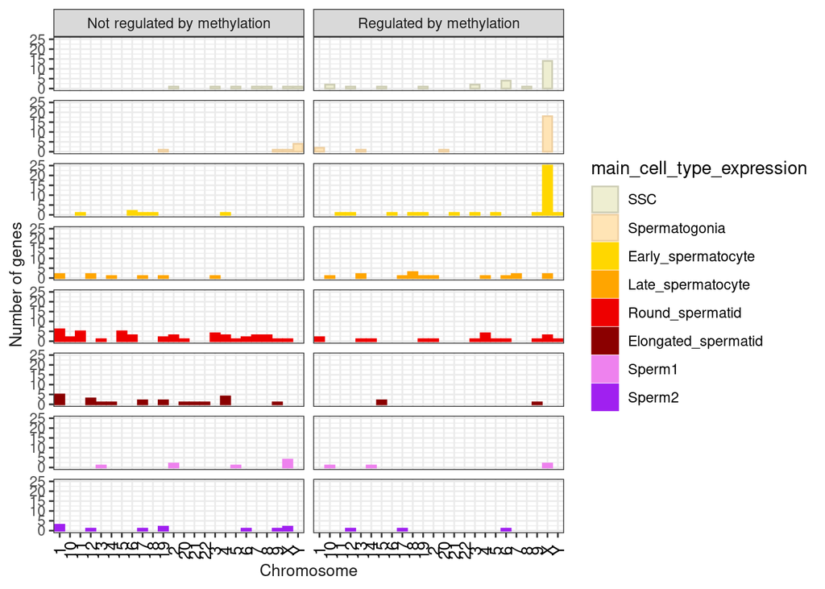

```r
CT_genes$main_cell_type_expression <- factor(CT_genes$testis_cell_type,
                                                levels = c("SSC",
                                               "Spermatogonia",
                                               "Early_spermatocyte",
                                               "Late_spermatocyte",
                                               "Round_spermatid",
                                               "Elongated_spermatid",
                                               "Sperm1",
                                               "Sperm2",
                                               "Sertoli"))

CT_genes %>%
  mutate(regulated_by_methylation = ifelse(regulated_by_methylation,
                                           "Regulated by methylation",
                                           "Not regulated by methylation")) %>%
  filter(!is.na(testis_cell_type)) %>%
  filter(main_cell_type_expression != "Sertoli") %>%
  ggplot(aes(x = chr, fill = main_cell_type_expression,
             color = main_cell_type_expression)) +
  scale_fill_manual(values = c("lightyellow2", "moccasin", "gold", "orange","red2",
                               "darkred", "violet", "purple")) +
  scale_color_manual(values = c("lightyellow3", "navajowhite2", "gold", "orange","red2",
                               "darkred", "violet", "purple")) +
  geom_bar(stat = 'count') +
  facet_grid(main_cell_type_expression ~ regulated_by_methylation) +
  xlab("Chromosome") +
  ylab("Number of genes") +
  theme_bw() +
  theme(
    axis.text.x = element_text(color = "black", angle = 90, vjust = 0.5, size = 10),
    axis.title = element_text(size = 10, color = "gray10"),
    strip.text.y = element_blank())
```

14 genes are on the X chromosome but escape X chromosome inactivation and are activates post-meioticly.

```r
CT_genes %>%
  filter(X_linked) %>%
  filter(testis_cell_type %in% c("Late_spermatocyte","Round_spermatid",
                                 "Elongated_spermatid", "Sperm1", "Sperm2"))
```

| ensembl_gene_id | external_gene_name | family | chr | strand | transcription_start_site | X_linked | TPM_testis | max_TPM_somatic | GTEX_category | lowly_expressed_in_GTEX | multimapping_analysis | testis_specificity | testis_cell_type | Higher_in_somatic_cell_type | percent_of_positive_CCLE_cell_lines | percent_of_negative_CCLE_cell_lines | max_TPM_in_CCLE | CCLE_category | percent_pos_tum | percent_neg_tum | max_TPM_in_TCGA | TCGA_category | DAC_induced | somatic_met_level | sperm_met_level | somatic_methylation | germline_methylation | regulated_by_methylation | CpG_density | … |
| --- | --- | --- | --- | --- | --- | --- | --- | --- | --- | --- | --- | --- | --- | --- | --- | --- | --- | --- | --- | --- | --- | --- | --- | --- | --- | --- | --- | --- | --- | --- |
| ENSG00000184735 | DDX53 | NA | X | 1 | 22999960 | TRUE | 11.5955000 | 0.007881985 | testis_specific | FALSE | NA | testis_specific | Round_spermatid | FALSE | 0.2 | 88.7 | 14.66 | activated | 0.31421838 | 90.36397 | 19.5593 | activated | TRUE | 89.78451 | 1.92307692 | TRUE | FALSE | TRUE | 2.2500000 | … |
| ENSG00000132446 | FTHL17 | NA | X | -1 | 31072041 | TRUE | 7.7046800 | 0.081030150 | testis_specific | FALSE | NA | testis_specific | Late_spermatocyte | FALSE | 0.5 | 98.2 | 68.17 | activated | 2.30426813 | 89.76172 | 361.6905 | activated | TRUE | 94.42574 | 1.23992921 | TRUE | FALSE | TRUE | 4.5833333 | … |
| ENSG00000189037 | DUSP21 | NA | X | 1 | 44844021 | TRUE | 20.4141000 | 0.000000000 | testis_specific | FALSE | NA | testis_specific | Sperm2 | FALSE | 0.1 | 98.7 | 30.92 | activated | 0.02618487 | 96.83163 | 12.1238 | activated | FALSE | 89.14681 | 23.55477132 | TRUE | FALSE | FALSE | 1.9166667 | … |
| ENSG00000215113 | CXorf49B | NA | X | 1 | 71763349 | TRUE | 0.0474703 | 0.000000000 | lowly_expressed | TRUE | testis_specific | testis_specific | Late_spermatocyte | FALSE | 1.8 | 80.6 | 59.90 | activated | 0.02618487 | 98.61220 | 10.2866 | multimapping_issue | TRUE | NaN | NaN | NA | NA | TRUE | 6.5833333 | … |
| ENSG00000153779 | TGIF2LX | NA | X | 1 | 89921908 | TRUE | 12.6297000 | 0.000000000 | testis_specific | FALSE | NA | testis_specific | Round_spermatid | FALSE | 1.1 | 88.2 | 24.72 | activated | 0.36658811 | 88.89762 | 25.0952 | activated | TRUE | 87.20455 | 1.20000000 | TRUE | FALSE | TRUE | 2.2500000 | … |
| ENSG00000204019 | CT83 | NA | X | -1 | 116462976 | TRUE | 104.2980000 | 1.130610000 | testis_preferential | FALSE | NA | testis_preferential | Sperm1 | FALSE | 11.1 | 78.5 | 214.92 | activated | 15.97276774 | 65.40979 | 310.9919 | activated | TRUE | 90.37542 | 0.82417582 | TRUE | FALSE | TRUE | 2.2500000 | … |
| ENSG00000186471 | AKAP14 | NA | X | 1 | 119895893 | TRUE | 66.0860000 | 1.184760000 | testis_preferential | FALSE | NA | testis_preferential | Sperm2 | FALSE | 0.1 | 69.2 | 10.12 | activated | 1.30924326 | 55.25007 | 78.3429 | activated | FALSE | 83.49026 | 96.53620189 | TRUE | TRUE | FALSE | 1.1666667 | … |
| ENSG00000227234 | SPANXB1 | SPANX | X | 1 | 141002594 | TRUE | 120.6910000 | 0.265889000 | testis_specific | FALSE | NA | testis_specific | Sperm1 | FALSE | 7.6 | 54.1 | 1351.20 | activated | 3.66588112 | 64.75517 | 2457.1365 | activated | TRUE | 88.26360 | 95.48449793 | TRUE | TRUE | FALSE | 2.1666667 | … |
| ENSG00000198573 | SPANXC | SPANX | X | -1 | 141242517 | TRUE | 11.0615000 | 0.000000000 | testis_specific | FALSE | NA | testis_specific | Sperm1 | FALSE | 3.7 | 71.8 | 398.97 | activated | 1.46635245 | 80.38754 | 822.3260 | activated | TRUE | 92.97201 | 62.12831613 | TRUE | TRUE | FALSE | 2.1666667 | … |
| ENSG00000196406 | SPANXD | SPANX | X | -1 | 141698739 | TRUE | 31.2012000 | 0.000000000 | testis_specific | FALSE | NA | testis_specific | Sperm1 | FALSE | 2.5 | 79.8 | 290.96 | activated | 0.83791568 | 89.42131 | 327.1508 | activated | TRUE | 78.68259 | 90.82699747 | TRUE | TRUE | FALSE | 1.7500000 | … |

[output cut: 4 more lines]

## 3.4 Gene function

```r
msigdbr(species = "Homo sapiens" , category = "C5") %>%
  filter(gene_symbol %in% CT_genes$external_gene_name) %>%
  pull(gene_symbol) %>%
  unique() %>%
  length()
```

```
## [1] 184
```

```r
msigdbr(species = "Homo sapiens" , category = "H") %>%
  filter(gene_symbol %in% CT_genes$external_gene_name) %>%
  pull(gene_symbol) %>%
  unique() %>%
  length()
```

```
## [1] 17
```

```r
go_ora <- enrichGO(gene = CT_genes$ensembl_gene_id,
                   keyType = "ENSEMBL",
                   OrgDb = org.Hs.eg.db,
                   ont = "all",
                   readable = TRUE)
as_tibble(go_ora)
```

| ONTOLOGY | ID | Description | GeneRatio | BgRatio | pvalue | p.adjust | qvalue | geneID | Count |
| --- | --- | --- | --- | --- | --- | --- | --- | --- | --- |
| BP | GO:0022412 | cellular process involved in reproduction in multicellular organism | 36/177 | 472/20772 | 4.765907e-24 | 3.765067e-21 | 3.446503e-21 | LIN28A/DMRTB1/BRDT/SYCP1/SPATA46/MAEL/C2CD6/TNP1/DAZL/MORC1/…… | 36 |
| BP | GO:0051321 | meiotic cell cycle | 25/177 | 316/20772 | 2.993019e-17 | 1.182243e-14 | 1.082213e-14 | BRDT/SYCP1/MAEL/ZFP42/PRDM9/DDX4/OOEP/ASZ1/DMRT1/SHOC1/TDRD1/MAJIN/SYCP3/PIWIL1/RPL10L/REC114/MEIOB/PRDM7/SPATA22/TEX14/TEX19/PSMA8/TDRD12/KASH5/FAM9A | 25 |
| BP | GO:0007281 | germ cell development | 25/177 | 346/20772 | 2.543043e-16 | 6.696680e-14 | 6.130072e-14 | LIN28A/DMRTB1/BRDT/SYCP1/C2CD6/TNP1/DAZL/ROPN1/ROPN1B/SPATA16/ADAD1/TCP11/SEPTIN14/DMRT1/TDRD1/SYCP3/PIWIL1/RNF17/SOHLH2/DRC7/TDRD12/ELSPBP1/KASH5/FAM9A/SPANXB1 | 25 |
| BP | GO:0140013 | meiotic nuclear division | 20/177 | 222/20772 | 4.478944e-15 | 8.845914e-13 | 8.097459e-13 | BRDT/SYCP1/MAEL/PRDM9/DDX4/OOEP/ASZ1/DMRT1/SHOC1/MAJIN/SYCP3/RPL10L/MEIOB/PRDM7/SPATA22/TEX14/TEX19/PSMA8/TDRD12/KASH5 | 20 |
| BP | GO:1903046 | meiotic cell cycle process | 20/177 | 242/20772 | 2.343121e-14 | 3.702132e-12 | 3.388893e-12 | BRDT/SYCP1/MAEL/PRDM9/DDX4/OOEP/ASZ1/DMRT1/SHOC1/MAJIN/SYCP3/RPL10L/MEIOB/PRDM7/SPATA22/TEX14/TEX19/PSMA8/TDRD12/KASH5 | 20 |
| BP | GO:0007127 | meiosis I | 16/177 | 152/20772 | 2.440010e-13 | 3.212680e-11 | 2.940854e-11 | BRDT/SYCP1/MAEL/PRDM9/DDX4/DMRT1/SHOC1/MAJIN/SYCP3/RPL10L/MEIOB/PRDM7/SPATA22/TEX19/PSMA8/KASH5 | 16 |
| BP | GO:0061982 | meiosis I cell cycle process | 16/177 | 159/20772 | 4.944192e-13 | 5.579874e-11 | 5.107759e-11 | BRDT/SYCP1/MAEL/PRDM9/DDX4/DMRT1/SHOC1/MAJIN/SYCP3/RPL10L/MEIOB/PRDM7/SPATA22/TEX19/PSMA8/KASH5 | 16 |
| BP | GO:0007286 | spermatid development | 17/177 | 216/20772 | 4.985929e-12 | 4.923605e-10 | 4.507017e-10 | BRDT/SYCP1/C2CD6/TNP1/ROPN1/ROPN1B/SPATA16/ADAD1/TCP11/SEPTIN14/SYCP3/PIWIL1/RNF17/DRC7/ELSPBP1/FAM9A/SPANXB1 | 17 |
| BP | GO:0048515 | spermatid differentiation | 17/177 | 223/20772 | 8.316587e-12 | 7.300115e-10 | 6.682450e-10 | BRDT/SYCP1/C2CD6/TNP1/ROPN1/ROPN1B/SPATA16/ADAD1/TCP11/SEPTIN14/SYCP3/PIWIL1/RNF17/DRC7/ELSPBP1/FAM9A/SPANXB1 | 17 |
| BP | GO:0007140 | male meiotic nuclear division | 10/177 | 55/20772 | 3.282307e-11 | 2.593022e-09 | 2.373626e-09 | BRDT/MAEL/DDX4/ASZ1/SYCP3/RPL10L/MEIOB/TEX14/TEX19/TDRD12 | 10 |

[output cut: 79 more lines]

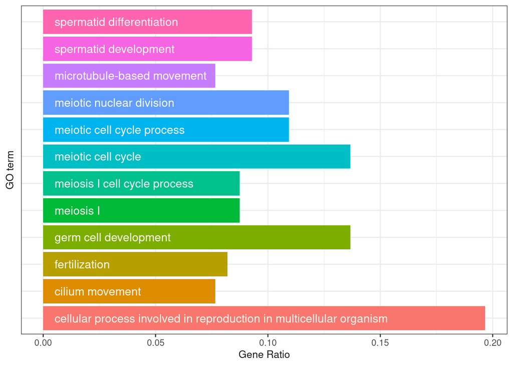

```r
as_tibble(go_ora) %>%
  arrange(desc(Count)) %>%
  head(12) %>%
  mutate(Ratio = Count/183) %>%
  ggplot(aes(x = Ratio, y = Description, fill = Description)) +
  geom_col() +
  theme_bw() +
  ylab("GO term") +
  xlab("Gene Ratio") +
  theme(axis.text.y = element_blank(),
        legend.position = "none",
        axis.ticks.y = element_blank(),
        axis.title = element_text(size = 10, color = "gray10"))+
  geom_text(aes(0, y = Description, label = Description),
            hjust = 0,
            nudge_x = 0.005,
            colour = "floralwhite",
            size = 4)
```

As we can see here, most of genes are indeed linked to functions from reproduction. I represented here the 12 categories with the most genes, all from biological processes. However, they are enriched in 89 different GO terms.

We’ve also added a column tumor suppressor and oncogene in CTexploreR. These information come from Cancermine.

```r
table(CT_genes$oncogene)
```

```
##
## oncogene
##       34
```

```r
table(CT_genes$tumor_suppressor)
```

```
##
## tumor_suppressor
##               15
```

```r
table(CT_genes$oncogene, CT_genes$tumor_suppressor)
```

```
##
##            tumor_suppressor
##   oncogene                9
```